# Transgenic mice gene signature in human colon cancer

# Below are heatmaps of DGE in genes for G12D and follow by G13D

[figure not shown]

[figure not shown]

# Hclust of human samples based on DGE found in Mouse (G12D vs WT) and Human ( G12D vs WT)

- Note for humans, WT is defined as any samples that do not have any KRAS mutations.

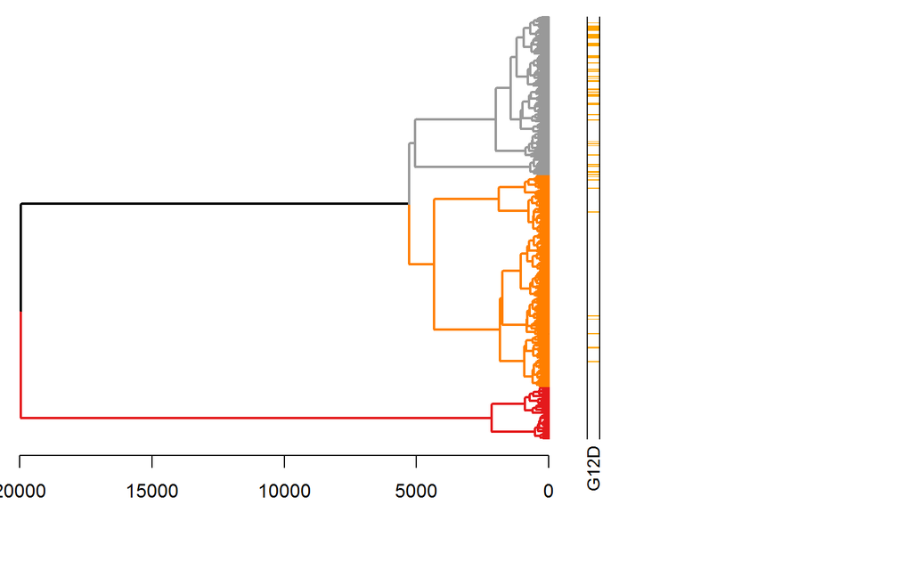

# Hclust of human samples based on DGE found in Mouse (G13D vs WT) and Human ( G13D vs WT)

- Note for humans, WT is defined as any samples that do not have any KRAS mutations.

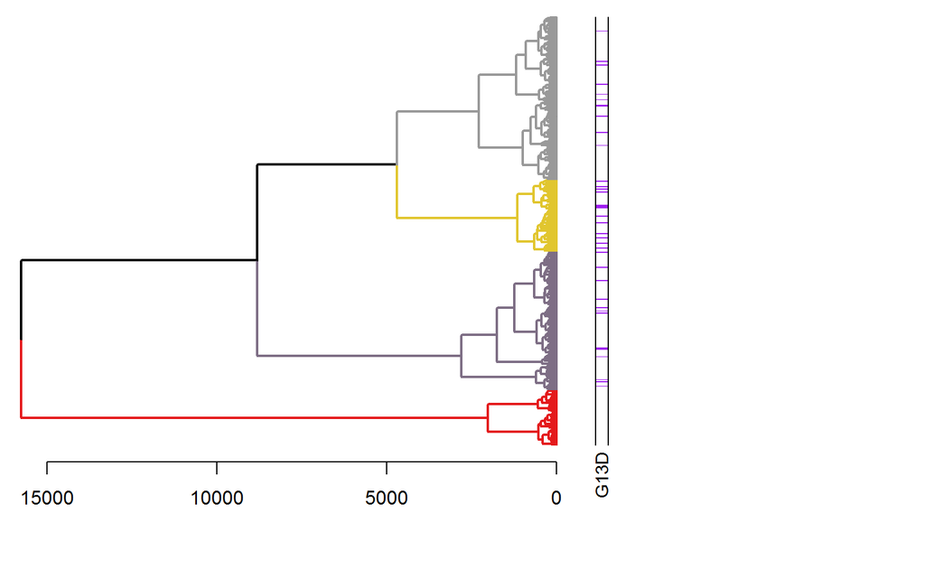

# Now we run pathway analysis for human and then compare it to mouse for that particular genotype

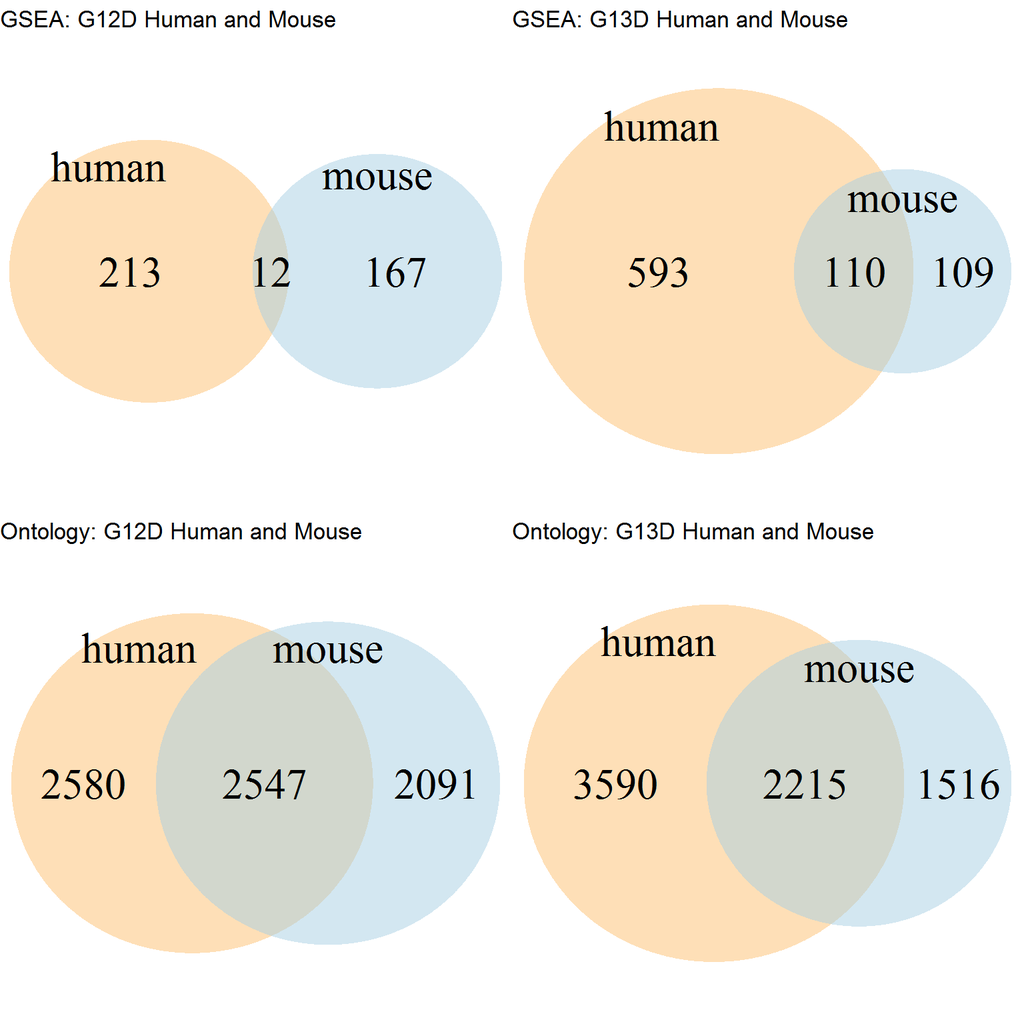